# Ep-06

Equipo 3

2026-05-08

# Contexto:

### En forma similar a la actividad anterior, recordemos que la prueba T de Student permite comparar dos mediciones pareadas de una variable aleatoria, que usualmente provienen de un mismo grupo de individuos u objetos. Ahora estamos conociendo que el análisis de varianza (ANOVA) nos permite comparar más de dos mediciones pareadas. Recordemos que esta prueba está compuesta de una etapa ómnibus, más un análisis post-hoc si corresponde. Este ejercicio apunta a que practiquemos este procedimiento.

# Equipo 3:

### 1. En este momento, los investigadores buscan determinar si existen diferencias en el tiempo que tardan los usuarios en formular consultas para problemas con diferente nivel de dificultad en el área de química.

¿Qué debemos determinar o resolver ? Debemos determinar si existen diferencias en el tiempo que tardan los usuarios en formular consultas para problemas con diferente nivel de dificultad.

Para ello se comienza con el análisis Primero filtramos los datos por el área “Química” y analizamos el impacto de la dificultad (Baja, Media, Alta) en el tiempo, considerando que cada participante pasa por los tres niveles.

```r
# Carga y filtrado de datos
datos <- read.csv("EP06 Datos.csv", stringsAsFactors = TRUE)

# Filtramos solo el área de Química
datos_quimica <- datos %>% filter(area == "Química")
```

Ahora planteamos las hipótesis:

Hipótesis Nula (H0): No existen diferencias significativas en el tiempo promedio que tardan los usuarios en formular consultas para los diferentes niveles de dificultad en el área de química ($\mu_{baja} = \mu_{media} = \mu_{alta}$). Hipótesis Alternativa (H_A): Al menos uno de los tiempos promedio de formulación de consultas es diferente para algún nivel de dificultad en el área de química.

Antes de proceder, verificamos las condiciones para aplicar un ANOVA de muestras correlacionadas:

Variable Independiente: Categórica con niveles vinculados (mismos sujetos evalúan las distintas dificultades).

Variable Dependiente: Escala de intervalo o razón (Tiempo en segundos).

Normalidad: Los datos deben seguir una distribución normal.

Esfericidad: Las varianzas de las diferencias entre todos los pares de niveles deben ser iguales (Prueba de Mauchly).

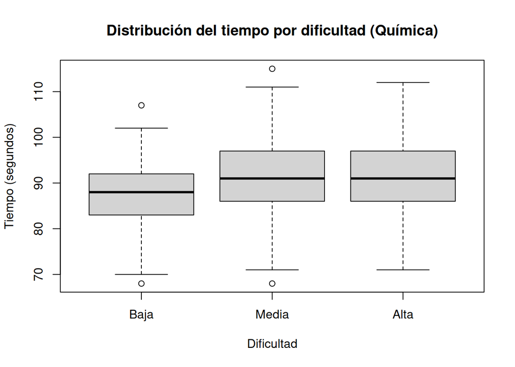

```r
# Nos aseguramos de que los tipos de datos sean correctos para ANOVA
datos_quimica$dificultad <- factor(datos_quimica$dificultad, levels = c("Baja", "Media", "Alta"))
datos_quimica$id <- factor(datos_quimica$id)

# Verificación mediante gráfico
boxplot(tiempo ~ dificultad, data = datos_quimica,
        main = "Distribución del tiempo por dificultad (Química)",
        ylab = "Tiempo (segundos)", xlab = "Dificultad")
```

```r
# Evaluamos la normalidad para cada grupo de dificultad
shapiro_resultados <- datos_quimica %>%
  group_by(dificultad) %>%
  summarise(p_value = shapiro.test(tiempo)$p.value)

shapiro_resultados
```

```
## # A tibble: 3 × 2
##   dificultad p_value
##   <fct>        <dbl>
## 1 Baja         0.318
## 2 Media        0.874
## 3 Alta         0.511
```

```r
# Ahora si el p-value > 0.05 en todos los grupos, se asume normalidad.
```

Prueba Ómnibus y Esfericidad:  
Para verificar el supuesto de esfericidad, se revisará la prueba de Mauchly incluida en los resultados de ezANOVA.  
Si el p-valor de Mauchly es $> 0.05$, se asume esfericidad y leemos los resultados estándar.  
Si es $< 0.05$, el supuesto no se cumple y debemos leer los resultados aplicando la corrección de Greenhouse-Geisser (p[GG]).

```r
anova_resultado <- ezANOVA(
  data = datos_quimica,
  dv = tiempo,
  wid = id,
  within = dificultad,
  return_aov = TRUE
)
anova_resultado
```

```
## $ANOVA
##       Effect DFn DFd       F            p p<.05        ges
## 2 dificultad   2 398 19.6332 7.383407e-09     * 0.06488883
##
## $`Mauchly's Test for Sphericity`
##       Effect         W         p p<.05
## 2 dificultad 0.9899065 0.3662881
##
## $`Sphericity Corrections`
##       Effect       GGe        p[GG] p[GG]<.05      HFe        p[HF] p[HF]<.05
## 2 dificultad 0.9900073 8.595725e-09         * 0.999906 7.393971e-09         *
##
## $aov
##
## Call:
## aov(formula = formula(aov_formula), data = data)
##
## Grand Mean: 89.99833
##
## Stratum 1: id
##
## Terms:
##                 Residuals
## Sum of Squares      10459
## Deg. of Freedom       199
##
## Residual standard error: 7.249675
##
## Stratum 2: id:dificultad
##
## Terms:
##                 dificultad Residuals
## Sum of Squares    2446.503 24797.497
## Deg. of Freedom          2       398
##
## Residual standard error: 7.893369
## Estimated effects may be unbalanced
```

Análisis Post-Hoc: Corresponde aplicar un análisis post-hoc si el resultado del ANOVA es significativo ($p < 0.05$), para determinar exactamente entre qué niveles de dificultad radican las diferencias.

```r
post_hoc <- pairwise.t.test(
  x = datos_quimica$tiempo,
  g = datos_quimica$dificultad,
  p.adjust.method = "holm",
  paired = TRUE
)
post_hoc
```

```
##
##  Pairwise comparisons using paired t tests
##
## data:  datos_quimica$tiempo and datos_quimica$dificultad
##
##       Baja    Media
## Media 2.1e-07 -
## Alta  3.0e-07 0.67
##
## P value adjustment method: holm
```

### 2. Propongan una pregunta de investigación relacionada a la influencia de distintas metodologías de desarrollo de software que necesite ser analizado por medio de un procedimiento ANOVA para muestras correlacionadas con un factor que tenga entre 4 y 6 niveles. Luego invente una población para cada grupo con 5.000 datos, asegurando que cumpla las suposiciones de esta prueba.

**Pregunta de investigación propuesta:** ¿Existen diferencias significativas en el tiempo (en horas) que tardan los mismos equipos de desarrollo en implementar un módulo de software estandarizado (como un CRUD para una API REST con persistencia en base de datos) al transicionar y aplicar 5 metodologías o marcos de trabajo distintos?

**Definición del diseño experimental:** Para que corresponda a un ANOVA de muestras correlacionadas (medidas repetidas), los mismos sujetos (en este caso, los equipos de desarrollo) deben pasar por todos los niveles del factor.

- **Sujetos:** Equipos de desarrollo de software.
- **Variable Independiente (Factor de medidas repetidas):** Metodología de desarrollo de software. Contará con **5 niveles**: Cascada, Scrum, Kanban, Extreme Programming (XP) y Lean.
- **Variable Dependiente:** Tiempo de implementación (en horas).

**Hipótesis:** * **Hipótesis Nula ($H_0$):** No existen diferencias en el tiempo promedio de implementación entre las distintas metodologías de desarrollo ($\mu_{Cascada} = \mu_{Scrum} = \mu_{Kanban} = \mu_{XP} = \mu_{Lean}$). * **Hipótesis Alternativa ($H_A$):** Al menos una de las metodologías de desarrollo presenta un tiempo promedio de implementación distinto a las demás para estos equipos.

**Generación de la Población (Simulación de Datos):** Para crear una población de 5.000 equipos, aseguraremos que la variable dependiente (tiempo en horas) provenga de una distribución normal para cada grupo. Además, configuraremos la matriz de correlación para que las diferencias entre las varianzas cumplan el supuesto de esfericidad (condición necesaria para este ANOVA).

```r
# Semilla para reproducibilidad
set.seed(42)

# Definir el número de sujetos (5000 equipos)
n_equipos <- 5000
niveles <- 5

limite_inferior <- 90
limite_superior <- 160

# Generación de medias aleatorias
medias <- runif(n = niveles, min = limite_inferior, max = limite_superior)

# Asignación a variables individuales para resolver el conflicto
mu_cascada <- medias[1]
mu_scrum   <- medias[2]
mu_kanban  <- medias[3]
mu_xp      <- medias[4]
mu_lean    <- medias[5]

# Verificación de las medias generadas aleatoriamente
print("Medias asignadas a cada metodología (en horas):")
```

```
## [1] "Medias asignadas a cada metodología (en horas):"
```

```r
print(setNames(medias, c("Cascada", "Scrum", "Kanban", "XP", "Lean")))
```

```
##  Cascada    Scrum   Kanban       XP     Lean
## 154.0364 155.5953 110.0298 148.1313 134.9222
```

```r
# Generamos los datos asumiendo una distribución normal para cada nivel.
# Para simplificar la generación de muestras correlacionadas que cumplan esfericidad,
# creamos un "efecto de equipo" base y le sumamos el efecto de la metodología
# con un ruido aleatorio normal.

efecto_equipo <- rnorm(n_equipos, mean = 0, sd = 15)

tiempo_cascada <- mu_cascada + efecto_equipo + rnorm(n_equipos, mean = 0, sd = 10)
tiempo_scrum   <- mu_scrum   + efecto_equipo + rnorm(n_equipos, mean = 0, sd = 10)
tiempo_kanban  <- mu_kanban  + efecto_equipo + rnorm(n_equipos, mean = 0, sd = 10)
tiempo_xp      <- mu_xp      + efecto_equipo + rnorm(n_equipos, mean = 0, sd = 10)
tiempo_lean    <- mu_lean    + efecto_equipo + rnorm(n_equipos, mean = 0, sd = 10)

# Armamos el dataframe en formato ancho y luego lo pasamos a formato largo
datos_poblacion_ancha <- data.frame(
  id_equipo = factor(1:n_equipos),
  Cascada = tiempo_cascada,
  Scrum = tiempo_scrum,
  Kanban = tiempo_kanban,
  XP = tiempo_xp,
  Lean = tiempo_lean
)

datos_poblacion <- datos_poblacion_ancha %>%
  pivot_longer(
    cols = c(Cascada, Scrum, Kanban, XP, Lean),
    names_to = "metodologia",
    values_to = "tiempo"
  ) %>%
  mutate(metodologia = factor(metodologia, levels = c("Cascada", "Scrum", "Kanban", "XP", "Lean")))

# Verificación rápida de los datos generados
head(datos_poblacion)
```

```
## # A tibble: 6 × 3
##   id_equipo metodologia tiempo
##   <fct>     <fct>        <dbl>
## 1 1         Cascada      159.
## 2 1         Scrum        155.
## 3 1         Kanban        95.8
## 4 1         XP           131.
## 5 1         Lean         126.
## 6 2         Cascada      144.
```

```r
summary(datos_poblacion)
```

```
##    id_equipo      metodologia       tiempo
##  1      :    5   Cascada:5000   Min.   : 48.14
##  2      :    5   Scrum  :5000   1st Qu.:124.43
##  3      :    5   Kanban :5000   Median :142.44
##  4      :    5   XP     :5000   Mean   :140.65
##  5      :    5   Lean   :5000   3rd Qu.:158.49
##  6      :    5                  Max.   :225.90
##  (Other):24970
```

```r
# Ejecución del ANOVA de medidas repetidas
anova_metodologias <- ezANOVA(
  data = datos_poblacion,
  dv = tiempo,
  wid = id_equipo,
  within = metodologia
)

# Visualización de los resultados
print(anova_metodologias)
```

```
## $ANOVA
##        Effect DFn   DFd        F p p<.05       ges
## 2 metodologia   4 19996 17299.59 0     * 0.4581449
##
## $`Mauchly's Test for Sphericity`
##        Effect         W         p p<.05
## 2 metodologia 0.9982696 0.4697028
##
## $`Sphericity Corrections`
##        Effect       GGe p[GG] p[GG]<.05      HFe p[HF] p[HF]<.05
## 2 metodologia 0.9991381     0         * 1.000037     0         *
```

```r
# Ejecución del análisis post-hoc con ajuste de Holm
post_hoc_metodologias <- pairwise.t.test(
  x = datos_poblacion$tiempo,
  g = datos_poblacion$metodologia,
  p.adjust.method = "holm",
  paired = TRUE
)

# Visualización de la matriz de comparaciones
print(post_hoc_metodologias)
```

```
##
##  Pairwise comparisons using paired t tests
##
## data:  datos_poblacion$tiempo and datos_poblacion$metodologia
##
##        Cascada Scrum   Kanban  XP
## Scrum  9.3e-16 -       -       -
## Kanban < 2e-16 < 2e-16 -       -
## XP     < 2e-16 < 2e-16 < 2e-16 -
## Lean   < 2e-16 < 2e-16 < 2e-16 < 2e-16
##
## P value adjustment method: holm
```